# Multivariate Time Series Forecasting: Nonparametric Vector Autoregression

Fred Viole

# 1 Introduction

This quick note is intended to introduce the intuition behind the `NNS.VAR` function, which serves as a nonparametric vector autoregression.

Install latest version of `NNS (>=0.4.7)` and other required packages…

```r
require(devtools)
install_github("OVVO-Financial/NNS", ref = "NNS-Beta-Version")

library(NNS)
library(vars)
library(forecast)
library(randomForest)

library(kableExtra)
```

# 2 `NNS.VAR` Example with 3 Variables: Fed Funds, Real GNP, and Inflation

Using the log differences of each `Real GNP` and `Inflation`, the previous method creates lowest frequency series. In this illustrative VAR example from Lutz Kilian[^1], `Fed Funds` (monthly) is averaged over 3-period windows to align with quarterly GNP data.

```r
# Load Variables
FF = read.csv("fedfunds.txt", header = FALSE, sep = "\t")

realgnp = read.csv("realgnp.txt", header = FALSE, sep = "\t")
drgdp = diff(log(realgnp[, 3])) * 100

gnpdeflator = read.csv("gnpdeflator.txt", header = FALSE, sep = "\t")
infl = diff(log(gnpdeflator[, 3])) * 100

irate = numeric()
for (i in seq(1, length(FF[, 3]), 3)) {
    irate[i] = mean(FF[i:(i + 2), 3])
}

irate = na.omit(irate)


y = cbind(`Diff Real GDP` = drgdp[1:213], `Interest Rate` = irate,
    Inflation = infl[1:213])

head(y)
```

```
##      Diff Real GDP Interest Rate Inflation
## [1,]     1.9944940     0.9866667 0.2810368
## [2,]     2.8100061     1.3433333 0.4818031
## [3,]     1.5928111     1.5000000 0.4148308
## [4,]     1.3345828     1.9400000 0.7089943
## [5,]     0.6089062     2.3566667 0.9778623
## [6,]    -0.3111535     2.4833333 0.9998818
```

```r
tail(y)
```

```
##        Diff Real GDP Interest Rate Inflation
## [208,]   -0.01158863      5.246667 0.6891565
## [209,]    0.84719231      5.246667 0.3501309
## [210,]    0.06757442      5.256667 1.1124581
## [211,]    0.91316852      5.250000 0.5562536
## [212,]    1.05338427      5.073333 0.3451964
## [213,]    0.66741511      4.496667 0.4471854
```

# 3 Forecast 12 Quarters Out-of-Sample Using All Methods

We will withhold 12 quarters of observations as the `test` set. Let’s see how accurate a VAR, a random forest and `NNS` are…

Why a random forest? The Bank of England has recently been posting working papers utilizing machine learning, specifically random forests:

- [Machine Learning at Central Banks](https://techpolicyinstitute.org/wp-content/uploads/2018/02/Joseph-machine-learning-at-central-banks.pdf)
- [Predicting Bank Distress in the UK with Machine Learning](https://www.bankofengland.co.uk/-/media/boe/files/working-paper/2019/predicting-bank-distress-in-the-uk-with-machine-learning.pdf)

# 4 Traditional VAR

```r
# Forecast next 12 quarters
h = 12

# Create train and test sets for both versions
y_train_VAR = head(y, dim(y)[1] - h)
y_test_VAR = tail(y, h)

# 4 quarterly lags used in VAR
VAR_train = VAR(y = y_train_VAR, p = 4)
VAR_test = predict(VAR_train, n.ahead = h)

par(mfrow = c(1, 3))


VAR_predictions_RMSE = cbind(rbind(Diff.Real.GDP = sqrt(mean((VAR_test$fcst[[1]][,
    1] - y_test_VAR[, 1])^2)), Interest.Rate = sqrt(mean((VAR_test$fcst[[2]][,
    1] - y_test_VAR[, 2])^2)), Inflation = sqrt(mean((VAR_test$fcst[[3]][,
    1] - y_test_VAR[, 3])^2))))

colnames(VAR_predictions_RMSE) = c("VAR Estimates RMSE to Actual Values")


VAR_predictions_corr = cbind(rbind(Diff.Real.GDP = cor(VAR_test$fcst[[1]][,
    1], y_test_VAR[, 1], method = "spearman"), Interest.Rate = cor(VAR_test$fcst[[2]][,
    1], y_test_VAR[, 2], method = "spearman"), Inflation = cor(VAR_test$fcst[[3]][,
    1], y_test_VAR[, 3], method = "spearman")))

colnames(VAR_predictions_corr) = c("VAR Estimates Correlation to Actual Values")

VAR_results = cbind(VAR_predictions_RMSE, VAR_predictions_corr)
knitr::kable(VAR_results, digits = 4) %>% kable_styling(full_width = T) %>%
    column_spec(1, width = "8cm")
```

|  | VAR Estimates RMSE to Actual Values | VAR Estimates Correlation to Actual Values |
| --- | --- | --- |
| Diff.Real.GDP | 0.5062 | -0.3916 |
| Interest.Rate | 1.3451 | 0.7741 |
| Inflation | 0.3481 | -0.6294 |

The correlations for the VAR forecast of `realgdp` and `inflation` versus the actual out-of-sample values were negative! The ARMA forecasts were negative for `realgdp` and `interest rates`.

This highlights the dual objective of differenced time series data:

- Get the sign right
- Get the magnitude right

`NNS` is able to address this dual objective into its routines as detailed in the following code chunks.

# 5 `NNS` and Random Forest

## 5.1 Function to Generate Lagged Variables

The following code is to generate a matrix of lagged variables to be used in both `NNS` and Random Forest routines.

```r
lag.mtx <- function(x, tau) {
    colheads <- NULL

    if (is.null(dim(x)[2])) {
        colheads <- noquote(as.character(deparse(substitute(x))))
        x <- t(t(x))
    }

    j.vectors <- list()

    for (j in 1:ncol(x)) {
        if (is.null(colheads)) {
            colheads <- colnames(x)[j]

            colheads <- noquote(as.character(deparse(substitute(colheads))))
        }

        x.vectors <- list()
        heads <- paste0(colheads, ".tau.")
        heads <- gsub("\"", "", heads)

        for (i in 0:tau) {
            x.vectors[[paste(heads, i, sep = "")]] <- numeric(0L)
            start <- tau - i + 1
            end <- length(x[, j]) - i
            x.vectors[[i + 1]] <- x[start:end, j]
        }

        j.vectors[[j]] <- do.call(cbind, x.vectors)
        colheads <- NULL
    }

    return(as.data.frame(do.call(cbind, j.vectors)))
}


# Test it
set.seed(123)
V1 <- rnorm(10)
V2 <- rnorm(10)
V3 <- rnorm(10)

lag.mtx(cbind(V1 = V1, V2 = V2, V3 = V3), 3)
```

| V1.tau.0 | V1.tau.1 | V1.tau.2 | V1.tau.3 | V2.tau.0 | V2.tau.1 | V2.tau.2 | V2.tau.3 | V3.tau.0 | V3.tau.1 | V3.tau.2 | V3.tau.3 |
| --- | --- | --- | --- | --- | --- | --- | --- | --- | --- | --- | --- |
| 0.07050839 | 1.55870831 | -0.23017749 | -0.56047565 | 0.1106827 | 0.4007715 | 0.3598138 | 1.2240818 | -0.7288912 | -1.0260044 | -0.2179749 | -1.0678237 |
| 0.12928774 | 0.07050839 | 1.55870831 | -0.23017749 | -0.5558411 | 0.1106827 | 0.4007715 | 0.3598138 | -0.6250393 | -0.7288912 | -1.0260044 | -0.2179749 |
| 1.71506499 | 0.12928774 | 0.07050839 | 1.55870831 | 1.7869131 | -0.5558411 | 0.1106827 | 0.4007715 | -1.6866933 | -0.6250393 | -0.7288912 | -1.0260044 |
| 0.46091621 | 1.71506499 | 0.12928774 | 0.07050839 | 0.4978505 | 1.7869131 | -0.5558411 | 0.1106827 | 0.8377870 | -1.6866933 | -0.6250393 | -0.7288912 |
| -1.26506123 | 0.46091621 | 1.71506499 | 0.12928774 | -1.9666172 | 0.4978505 | 1.7869131 | -0.5558411 | 0.1533731 | 0.8377870 | -1.6866933 | -0.6250393 |
| -0.68685285 | -1.26506123 | 0.46091621 | 1.71506499 | 0.7013559 | -1.9666172 | 0.4978505 | 1.7869131 | -1.1381369 | 0.1533731 | 0.8377870 | -1.6866933 |
| -0.44566197 | -0.68685285 | -1.26506123 | 0.46091621 | -0.4727914 | 0.7013559 | -1.9666172 | 0.4978505 | 1.2538149 | -1.1381369 | 0.1533731 | 0.8377870 |

```r
# Compare to last values of each variable
cbind(V1 = tail(V1), V2 = tail(V2), V3 = tail(V3))
```

```
##              V1         V2         V3
## [1,]  0.1292877 -0.5558411 -0.6250393
## [2,]  1.7150650  1.7869131 -1.6866933
## [3,]  0.4609162  0.4978505  0.8377870
## [4,] -1.2650612 -1.9666172  0.1533731
## [5,] -0.6868529  0.7013559 -1.1381369
## [6,] -0.4456620 -0.4727914  1.2538149
```

# 6 Predictions

## 6.1 1 Year Lag $(\tau = 4)$, 3 Year Forecast $(h = 12)$

## 6.2 Create Forecasted IVs Using `NNS.ARMA()`

```r
train_l = dim(y)[1] - h
test_DVs = tail(y, h)

nns_IVs = list()

cl <- makeCluster(detectCores() - 1)
registerDoParallel(cl)

nns_IVs <- foreach(i = 1:ncol(y_train_VAR), .packages = "NNS") %dopar%
    {
        variable = y_train_VAR[, i]

        periods = NNS.seas(variable, modulo = 4, mod.only = FALSE,
            plot = FALSE)$periods

        b = NNS.ARMA.optim(variable, seasonal.factor = periods,
            training.set = length(variable) - 2 * h, ncores = 1,
            print.trace = FALSE, obj.fn = expression(sum((predicted -
                actual)^2)), objective = "min")

        NNS.ARMA(variable, h = h, seasonal.factor = b$periods,
            weights = b$weights, method = b$method, ncores = 1,
            plot = FALSE) + b$bias.shift
    }

stopCluster(cl)
registerDoSEQ()

nns_IVs = do.call(cbind, nns_IVs)


# Combine forecasted IVs onto training data.frame
new_values = rbind(y_train_VAR, nns_IVs)

# Now lag new forecasted data.frame
lagged_new_values = lag.mtx(new_values, tau = 4)


# Test how accurate new univariate NNS.ARMA forecast IVs are
# Also add auto arima estimate...
NNS.ARMA_RMSEs = numeric()
NNS.ARMA_Correlations = numeric()
auto.ARMA_RMSEs = numeric()
auto.ARMA_Correlations = numeric()

arma.fit = list()

for (i in 1:3) {
    NNS.ARMA_RMSEs[i] = sqrt(mean((nns_IVs[, i] - test_DVs[,
        i])^2))
    NNS.ARMA_Correlations[i] = cor(nns_IVs[, i], test_DVs[, i],
        method = "spearman")
    fit = auto.arima(y_train_VAR[, i])
    arma.fit[[i]] = as.numeric(forecast(fit, h = h)$mean)
    auto.ARMA_RMSEs[i] = sqrt(mean((arma.fit[[i]] - test_DVs[,
        i])^2))
    auto.ARMA_Correlations[i] = cor(arma.fit[[i]], test_DVs[,
        i], method = "spearman")
}

NNS.ARMA_results = cbind(NNS.ARMA_RMSEs, NNS.ARMA_Correlations)

colnames(NNS.ARMA_results) = c("NNS ARMA RMSEs", "NNS ARMA Corr")

knitr::kable(cbind(VAR_results, NNS.ARMA_results, `Auto ARMA RMSEs` = auto.ARMA_RMSEs,
    `Auto ARMA Cor` = auto.ARMA_Correlations), digits = 4) %>%
    kable_styling(full_width = T) %>% column_spec(1, width = "8cm")
```

|  | VAR Estimates RMSE to Actual Values | VAR Estimates Correlation to Actual Values | NNS ARMA RMSEs | NNS ARMA Corr | Auto ARMA RMSEs | Auto ARMA Cor |
| --- | --- | --- | --- | --- | --- | --- |
| Diff.Real.GDP | 0.5062 | -0.3916 | 0.4194 | 0.2657 | 0.464 | -0.1329 |
| Interest.Rate | 1.3451 | 0.7741 | 0.9623 | -0.0315 | 2.631 | -0.4812 |
| Inflation | 0.3481 | -0.6294 | 0.3255 | 0.6364 | 0.227 | 0.3287 |

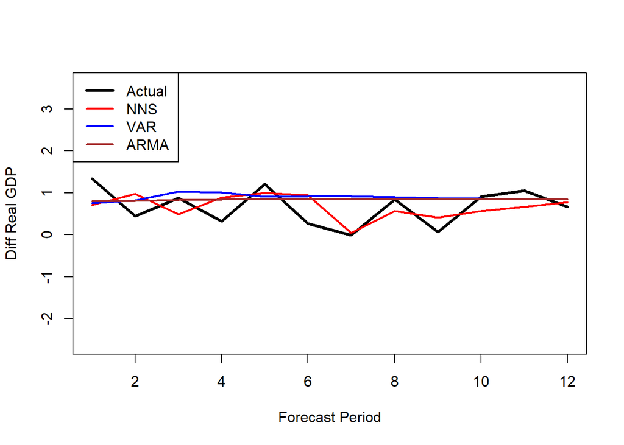

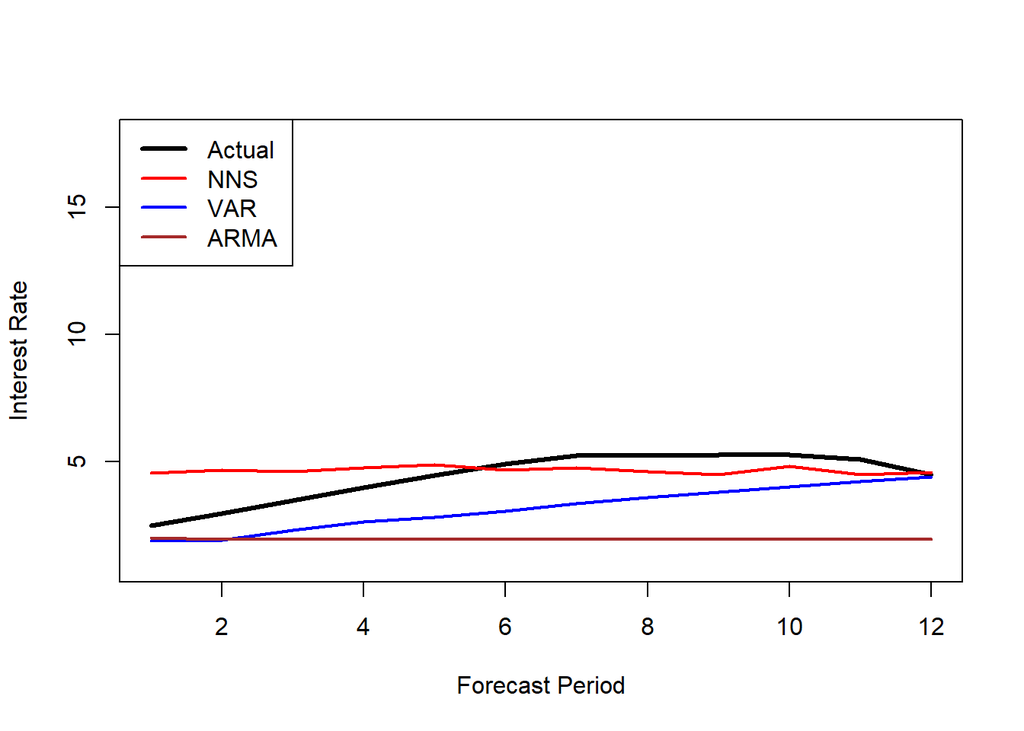

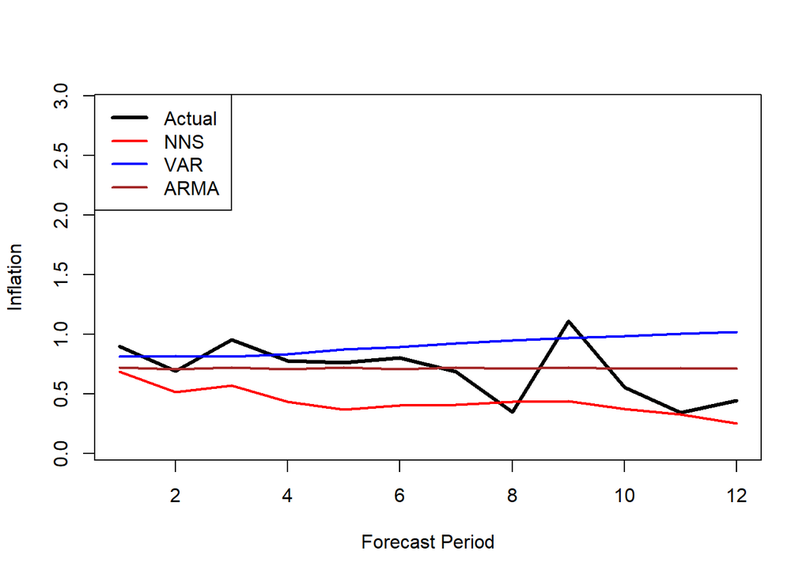

```r
for (i in 1:3) {
    plot(1:h, test_DVs[, i], type = "l", lwd = 3, ylim = c(min(new_values[,
        i]), max(new_values[, i])), xlab = "Forecast Period",
        ylab = colnames(new_values)[i])
    lines(1:h, nns_IVs[, i], col = "red", lwd = 2)
    lines(1:h, VAR_test$fcst[[i]][, 1], col = "blue", lwd = 2)
    lines(1:h, arma.fit[[i]], col = "brown", lwd = 2)
    legend("topleft", col = c("black", "red", "blue", "brown"),
        legend = c("Actual ", "NNS", "VAR", "ARMA"), lty = 1,
        lwd = c(3, 2, 2, 2))
}
```

```r
# Significant Difference in Distributions
for (i in 1:3) {
    print(paste0("NNS KS Test: ", suppressWarnings(ks.test(nns_IVs[,
        i], test_DVs[, i])$p.value)))
    print(paste0("ARMA KS Test: ", suppressWarnings(ks.test(arma.fit[[i]],
        test_DVs[, i])$p.value)))
}
```

```
## [1] "NNS KS Test: 0.868981671175775"
## [1] "ARMA KS Test: 0.0995467717099161"
## [1] "NNS KS Test: 0.0995618483147803"
## [1] "ARMA KS Test: 1.22884247066857e-05"
## [1] "NNS KS Test: 0.00785901405096467"
## [1] "ARMA KS Test: 0.0995467717099161"
```

# 7 Use Forecasted IVs in `NNS` and Random Forest

We will now utilize the forecasted variables in the multi-variate `NNS.reg()` function. Our first step is to pass these variables through the `NNS.boost()` function in order to reduce any unnecessary features. The objective function `obj.fn` and objective `objective` parameters in `NNS.boost()` need to be re-defined from their default values since this is not a classification problem.

From there, we use the reduced variable set (if any reduction) in the `NNS.stack()` function which cross- validates the `n.best` and `threshold` parameters from the `NNS.reg()` function.

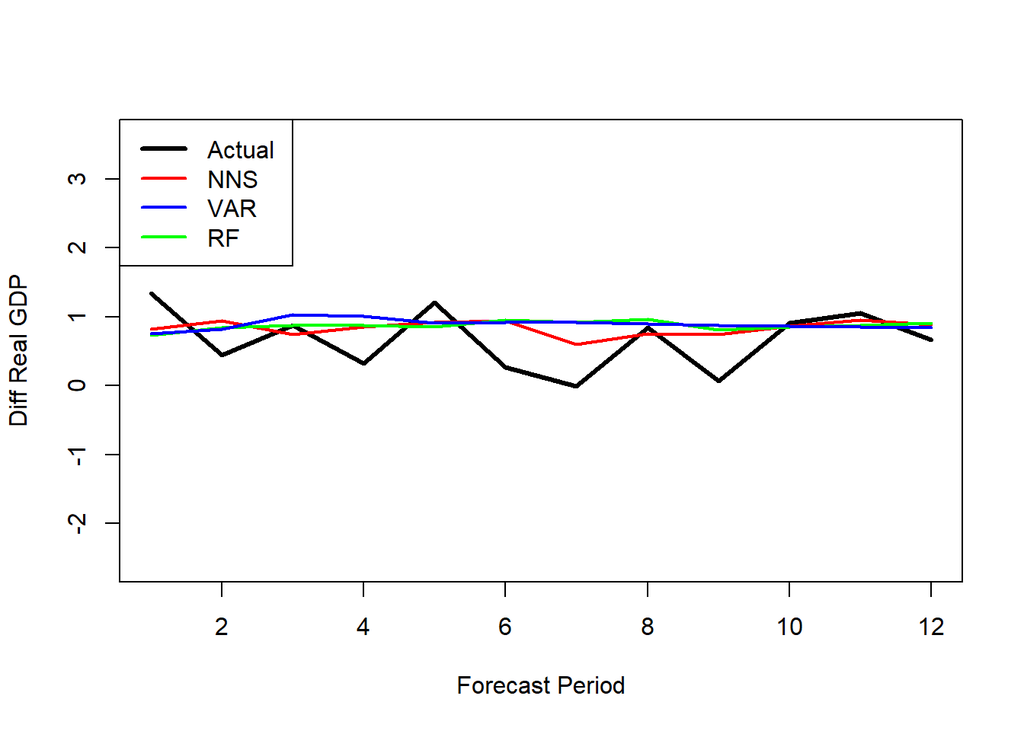

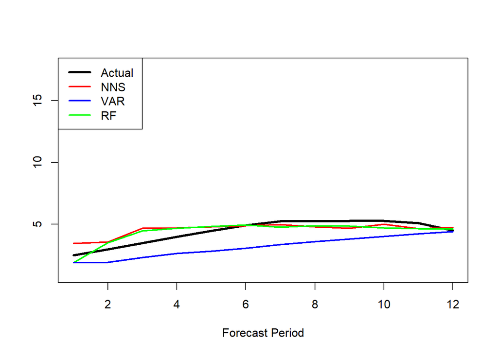

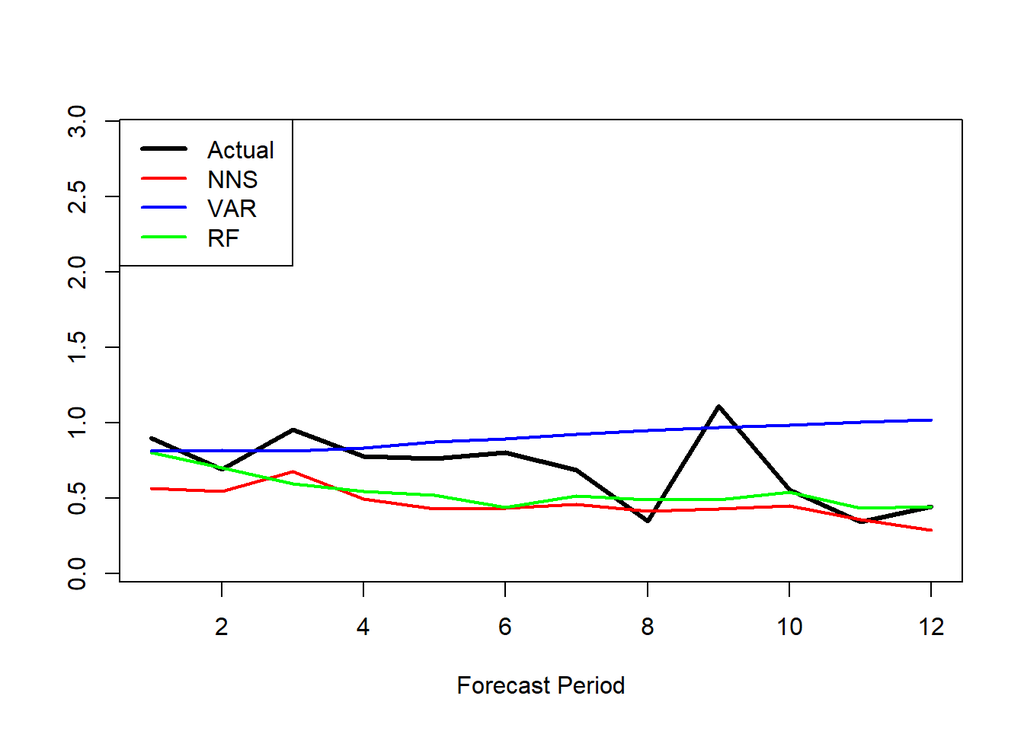

```r
y_train_nns = head(lagged_new_values, dim(lagged_new_values)[1] -
    h)
y_test_nns = tail(lagged_new_values, h)

# Select tau = 0 as test set DVs
DVs = which(grepl("tau.0", colnames(y_train_nns)))

nns_est = list()

NNS_est_RMSEs = numeric()
NNS_est_Correlations = numeric()

RF_RMSEs = numeric()
RF_Correlations = numeric()


for (i in DVs) {
    index = which(DVs == i)
    test.set = test_DVs[, index]

    # NNS.boost() is an ensemble method comparable to xgboost,
    # and aids in dimension reduction
    nns_boost_est = NNS.boost(IVs.train = y_train_nns[, -i],
        DV.train = y_train_nns[, i], IVs.test = y_test_nns[,
            -i], obj.fn = expression(sum((predicted - actual)^2)),
        objective = "min", ts.test = 2 * h, learner.trials = 100,
        epochs = 100, ncores = 1, type = NULL, feature.importance = FALSE,
        folds = 1)

    # NNS.stack() cross-validates the parameters of the
    # multivariate NNS.reg() and dimension reduction NNS.reg()
    relevant_vars = colnames(y_train_nns) %in% names(nns_boost_est$feature.weights)

    nns_reg_est = NNS.stack(IVs.train = y_train_nns[, relevant_vars],
        DV.train = y_train_nns[, i], IVs.test = y_test_nns[,
            relevant_vars], folds = 1, ts.test = 2 * h, order = "max",
        obj.fn = expression(sum((predicted - actual)^2)), objective = "min")$stack

    # Ensemble with univariate estimates
    nns_est[[index]] = (nns_IVs[, index] + nns_reg_est)/2

    # Random Forest
    rf = randomForest(y_train_nns[, -i], y_train_nns[, i], ntree = 100)
    rf.pred = predict(rf, newdata = y_test_nns[, -i])

    # Print all results
    NNS_est_RMSEs[index] = sqrt(mean((nns_est[[index]] - test.set)^2))
    RF_RMSEs[index] = sqrt(mean((rf.pred - test.set)^2))

    NNS_est_Correlations[index] = cor(nns_est[[index]], test.set,
        method = "spearman")
    RF_Correlations[index] = cor(rf.pred, test.set, method = "spearman")


    # Plot all results
    plot(1:12, test_DVs[, index], type = "l", lwd = 3, ylim = c(min(new_values[,
        index]), max(new_values[, index])), xlab = "Forecast Period",
        ylab = colnames(new_values)[i])
    lines(1:12, nns_est[[index]], col = "red", lwd = 2)
    lines(1:12, rf.pred, col = "green", lwd = 2)
    lines(1:12, VAR_test$fcst[[index]][, 1], col = "blue", lwd = 2)
    legend("topleft", col = c("black", "red", "blue", "green"),
        legend = c("Actual ", "NNS", "VAR", "RF"), lty = 1, lwd = c(3,
            2, 2, 2))
}
```

```r
ALL_RESULTS = cbind(VAR_results, NNS.ARMA_results, `NNS RMSEs` = NNS_est_RMSEs,
    `NNS Corr` = NNS_est_Correlations, `RF RMSEs` = RF_RMSEs,
    `RF Corr` = RF_Correlations)

knitr::kable(ALL_RESULTS, digits = 4) %>% kable_styling(full_width = T) %>%
    column_spec(1, width = "8cm")
```

|  | VAR Estimates RMSE to Actual Values | VAR Estimates Correlation to Actual Values | NNS ARMA RMSEs | NNS ARMA Corr | NNS RMSEs | NNS Corr | RF RMSEs | RF Corr |
| --- | --- | --- | --- | --- | --- | --- | --- | --- |
| Diff.Real.GDP | 0.5062 | -0.3916 | 0.4194 | 0.2657 | 0.4335 | 0.3007 | 0.4949 | -0.3497 |
| Interest.Rate | 1.3451 | 0.7741 | 0.9623 | -0.0315 | 0.6032 | 0.5814 | 0.5211 | 0.7110 |
| Inflation | 0.3481 | -0.6294 | 0.3255 | 0.6364 | 0.3031 | 0.5804 | 0.2631 | 0.4056 |

# 8 `NNS.VAR()`

The `NNS.VAR()` function now accomplishes all of the prior steps in a single line of code. `NNS.VAR` does take the additional step of weighting each estimate by its objective function result.

```r
nns_var_estimates = NNS.VAR(y_train_VAR, h = 12, tau = 4, ncores = 1)

nns_var_estimates
```

```
## $univariate
##       Diff Real GDP Interest Rate Inflation
##  [1,]    0.71182079      4.536222 0.6891101
##  [2,]    0.97198238      4.655889 0.5132415
##  [3,]    0.49344043      4.603333 0.5697954
##  [4,]    0.89140137      4.737889 0.4357171
##  [5,]    1.00169992      4.871167 0.3667949
##  [6,]    0.93692811      4.665000 0.4023420
##  [7,]    0.04796763      4.750889 0.4080647
##  [8,]    0.56628191      4.603222 0.4370086
##  [9,]    0.41366022      4.474333 0.4392642
## [10,]    0.56131736      4.821333 0.3732100
## [11,]    0.67121142      4.492222 0.3300415
## [12,]    0.77318203      4.568333 0.2547801
##
```

[output cut: 29 more lines]

```r
NNS_VAR_RMSEs = numeric()
NNS_VAR_corr = numeric()

for (i in 1:3) {
    NNS_VAR_RMSEs[i] = sqrt(mean((nns_var_estimates$ensemble[,
        i] - test_DVs[, i])^2))

    NNS_VAR_corr[i] = cor(nns_var_estimates$ensemble[, i], test_DVs[,
        i], method = "spearman")
}

NNS_VAR_results = cbind(NNS_VAR_RMSEs, NNS_VAR_corr)
rownames(NNS_VAR_results) = colnames(y_train_VAR)
knitr::kable(NNS_VAR_results, digits = 4) %>% kable_styling(full_width = T) %>%
    column_spec(1, width = "8cm")
```

|  | NNS_VAR_RMSEs | NNS_VAR_corr |
| --- | --- | --- |
| Diff Real GDP | 0.4082 | 0.2657 |
| Interest Rate | 0.4855 | 0.8231 |
| Inflation | 0.2963 | 0.5175 |

[^1]: Data available for download at the following: https://sites.google.com/site/lkilian2019/